# Testing the robustness of hydrophone array detections

James Campbell

2017-11-06

### Overview

Here, we’ll try to estimate the error of our hydrophone array using simulations. The simulation will contain error due to moving hydrophones (such as those attached to a floating platform) and the sample rate of the system.

### Create a simulated dataset

The code below will create a simulated array of 4 hydrophones and randomly place multiple sound sources within a defined area around the array. We’ll also add the error due to the hydrophone sampling rate and movement to our simulated detections, while remembering the real locations of the sources.

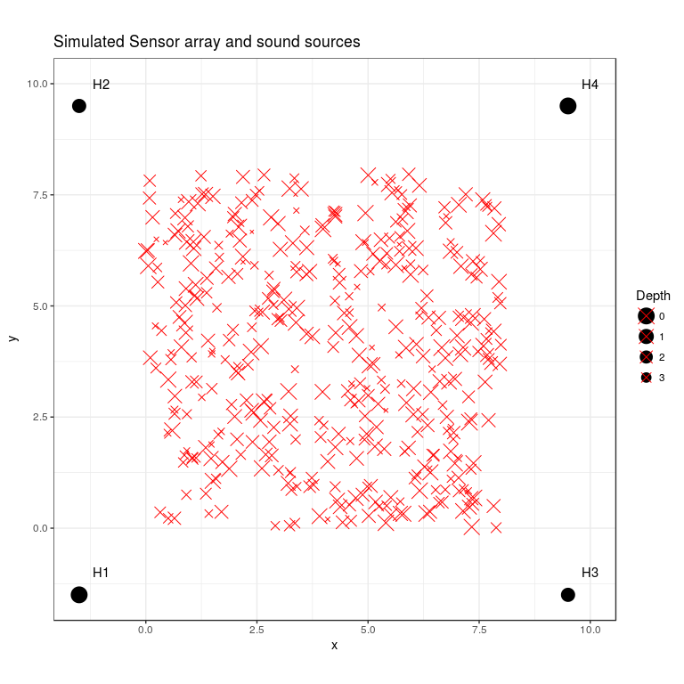

```r
## Define a simulated sensor array.
# Hydrophones are arranged in a rectangle with the following lateral and depth
# distances along the edges of the array.
dist.lateral <- 11
dist.depth <- 1.5

## Define a rectangle where the sources will be randomly placed
source.lateral <- 8
source.depth <- 4

## The sampling rate of the simulated hydrophone array
# This simulate the resolution of a real hydrophone array.
fs <- 12000

## Maximum error due to hydrophone movement
# This will be used to create a random uniform distribution of hydrophopne position errors
movement.error <- 0.05

## Begin creating simulated dataset
require(ggplot2)
require(toal)
## Generate hydrophone positions
lat.low <- (source.lateral/2) - (dist.lateral/2)
lat.high <- (source.lateral/2) + (dist.lateral/2)
sensorLocations <- data.frame(x = c(lat.low, lat.low, lat.high, lat.high),
                              y = c(lat.low, lat.high, lat.low, lat.high),
                              z = c(0, dist.depth,dist.depth, 0),
                              row.names = paste0('H',1:4))

## Create 5 random source locations within array
n <- 400 # point sources to simulate
sourceLocation <- data.frame(x = runif(n = n,min = 0, max = source.lateral),
                             y = runif(n = n,min = 0, max = source.lateral),
                             z = runif(n = n,min = 0, max = source.depth))

## Calculate simulated arrival delays
N <- nrow(sensorLocations) # Number of sensors
c <- 1500 # Speed of sound in water

## Function for calculating distance between points
dist <- function(a,b){
  ## Calc distance between two locations
  dif <- abs(a - b)
  return(sqrt(sum(dif^2)))
}

# Initalize empty array
sensorLatency = matrix(ncol = N,nrow = nrow(sourceLocation))
# Calculate distances from each source
for(i in 1:N){
  for(j in 1:nrow(sourceLocation)){
    sensorLatency[j,i] <- dist(sourceLocation[j,],sensorLocations[i,1:3])
  }
}
rownames(sensorLatency) <- paste0('Source ',1:nrow(sourceLocation))
colnames(sensorLatency) <- paste0('Hydrophone ',1:N)

## Add random uniform error to each distance
errorvals.movement <- runif(min = movement.error/-2, max = movement.error/2,n = length(sensorLatency))
sensorLatency <- sensorLatency + errorvals.movement

## Convert distances to arrival latencies (from meters to seconds)
sensorLatency <- sensorLatency/c

## Apply error due to minimum sample rate
dt <- 1/fs
# dt is the sample period (i.e. minimum time between detections)
sensorLatency <- round(sensorLatency/dt,digits = 0)*dt

## Plot resulting source locations and location estimates
nudge <- 0.5
ggplot(sensorLocations) +
  geom_point(aes(x = x, y = y, size = z)) +
  geom_point(data = sourceLocation,
             aes(x = x, y = y, size = z),
             color = 'red', pch = 4) +
  geom_text(aes(x = x, y = y, label = rownames(sensorLocations)),
            nudge_x = nudge, nudge_y = nudge) +
  theme_bw() + coord_equal() +
  scale_size_continuous(name = 'Depth',trans = 'reverse') +
  ggtitle('Simulated Sensor array and sound sources')
```

### Calculate position estimates from simulated sources

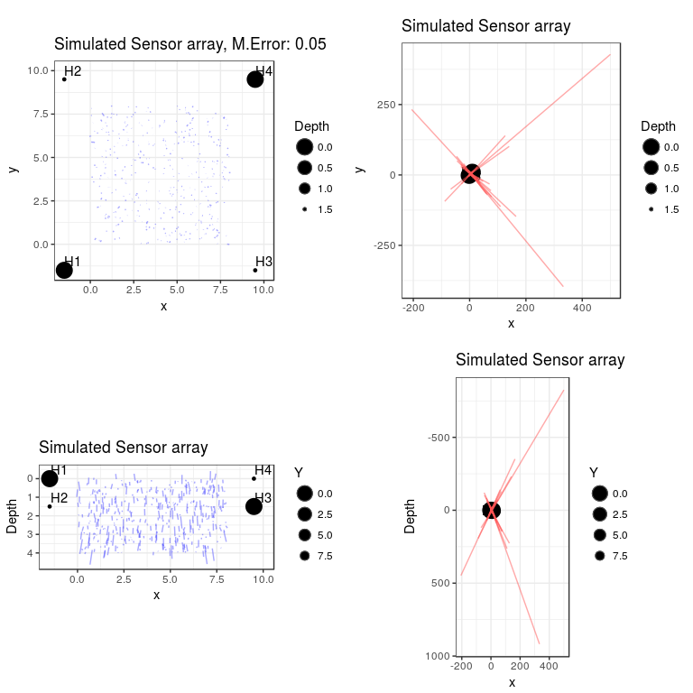

```r
sourceEstimates <- TOA.localization(toa = sensorLatency,
                                    hydrohpone.positions = sensorLocations,
                                    c = c)
results <- rbind(sourceEstimates,
                 data.frame(sourceLocation,
                            id = as.numeric(rownames(sourceLocation)),
                            error = 0,
                            eq = 'real',stringsAsFactors = F))
############################################################
## Plot resulting source locations and location estimates ##
############################################################
require(gridExtra)
#### Plot sensor locations
plot.sensors.xy <- ggplot(data = results) +
  geom_point(data = sensorLocations,
             aes(x = x, y = y, size = z)) +
  geom_text(data = sensorLocations,
            aes(x = x, y = y, label = rownames(sensorLocations)),
            nudge_x = nudge, nudge_y = nudge)
plot.sensors.xz <- ggplot(data = results) +
  geom_point(data = sensorLocations,
             aes(x = x, y = z, size = y)) +
  geom_text(data = sensorLocations,
            aes(x = x, y = z, label = rownames(sensorLocations)),
            nudge_x = nudge, nudge_y = nudge)

alpha.line <- 0.5

#### Plot xy location estimates
cols <- c('#ff5555','#555555','#5555ff')
plot.1 <- plot.sensors.xy +
  geom_point(data = subset(results, subset = id %in% 'real'),
             aes(x = x, y = y, size = z),
                 color = cols[2],
                 shape = 1) +
  theme_bw() + coord_equal() +
  geom_line(data = subset(results, subset = eq %in% c('+','real')),
            aes(x = x, y = y, group = factor(id)),
            color = cols[3], alpha = alpha.line) +
  scale_size_continuous(name = 'Depth',trans = 'reverse') +
  ggtitle(paste0('Simulated Sensor array, M.Error: ', movement.error))


plot.2 <- plot.sensors.xy +
  geom_point(data = subset(results, subset = id %in% 'real'),
             aes(x = x, y = y, size = z),
                 color = cols[2],
                 shape = 1) +
  theme_bw() + coord_equal() +
  geom_line(data = subset(results, subset = eq %in% c('-','real')),
            aes(x = x, y = y, group = factor(id)),
            color = cols[1], alpha = alpha.line) +
  scale_size_continuous(name = 'Depth',trans = 'reverse') +
  ggtitle('Simulated Sensor array')

#### Plot xz location estimates
plot.3 <- plot.sensors.xz +
  geom_point(data = subset(results, subset = id %in% 'real'),
             aes(x = x, y = z, size = z),
                 color = cols[2],
                 shape = 1) +
  theme_bw() + coord_equal() +
  geom_line(data = subset(results, subset = eq %in% c('+','real')),
            aes(x = x, y = z, group = factor(id)),
            color = cols[3], alpha = alpha.line) +
  scale_size_continuous(name = 'Y',trans = 'reverse') +
  scale_y_reverse() +
  ggtitle('Simulated Sensor array') +
  ylab('Depth')


plot.4 <- plot.sensors.xz +
  geom_point(data = subset(results, subset = id %in% 'real'),
             aes(x = x, y = z, size = z),
                 color = cols[2],
                 shape = 1) +
  theme_bw() + coord_equal() +
  geom_line(data = subset(results, subset = eq %in% c('-','real')),
            aes(x = x, y = z, group = factor(id)),
            color = cols[1], alpha = alpha.line) +
  scale_size_continuous(name = 'Y',trans = 'reverse') +
    scale_y_reverse() +
  ggtitle('Simulated Sensor array') +
  ylab('Depth')

  grid.arrange(plot.1, plot.2,
               plot.3, plot.4, ncol = 2)
```